# Bioestadística Fundamental

Departamento de Estadística, Sede Bogotá

## Clase 28

## Contenido

### Parte I: Diseño anidado de dos etapas

- Factores cruzados vs. factores anidados.
- Ejemplo: materia orgánica en lotes anidados en fincas.
- Modelo, descomposición de SC y tabla ANOVA.
- Verificación diagnóstica de residuos.
- Componentes de varianza.
- Diseños anidados escalonados.

### Parte II: Generalizaciones del anidado

- Diseño anidado general de $m$ etapas.
- Factores anidados y factoriales combinados.

### Parte III: Parcelas divididas (split-plot)

- Motivación: factores difíciles de cambiar.
- Ejemplo: riego (parcela principal) y variedad de arroz (subparcela).
- Modelo, tabla ANOVA y precisión diferencial.

### Parte IV: Otras variaciones

- Split-plot con más de dos factores.
- Diseño split-split-plot.
- Diseño en franjas divididas (strip-split-plot).

Diseños Anidados y de Parcelas Divididas

¿Qué hacer cuando los niveles de un factor solo tienen sentido dentro de otro factor, o cuando un factor es muy costoso de cambiar entre unidades experimentales?

## Motivación: factores cruzados vs. anidados

En los diseños factoriales estudiados hasta ahora, los factores son **cruzados**: cada nivel de un factor se combina con cada nivel del otro. Pero en muchos estudios agropecuarios esto no es posible ni tiene sentido.

Ejemplo: si se seleccionan 3 **lotes** dentro de cada una de 4 **fincas** cafeteras del Quindío, el “lote 1” de la finca La Esperanza no es la misma unidad física que el “lote 1” de la finca El Vergel. Son etiquetas distintas que solo tienen sentido dentro de su finca.

Cuando los niveles de un factor B solo existen dentro de un nivel específico de otro factor A, se dice que B está **anidado** en A, y se escribe $B(A)$.

## Factor cruzado vs. factor anidado

Factores cruzados

Ejemplo: variedad de café $\times$ tipo de fertilizante. Cada variedad se evalúa con **todos** los fertilizantes. Tiene sentido hablar del efecto de interacción.

Factores anidados

Ejemplo: lote dentro de finca. Cada lote pertenece a **una sola** finca. No existe interacción finca $\times$ lote en el sentido factorial clásico.

Otros ejemplos agrícolas: parcela dentro de bloque, vaca dentro de hato, planta dentro de surco, rama dentro de árbol.

## Ejemplo introductorio: materia orgánica del suelo

Un agrónomo del Quindío quiere caracterizar el contenido de **materia orgánica del suelo (%)** en cuatro fincas cafeteras. En cada finca se seleccionan al azar 3 lotes, y en cada lote se toman 3 submuestras de suelo.

Estructura: 4 fincas $\times$ 3 lotes anidados en cada finca $\times$ 3 submuestras por lote = 36 observaciones.

¿Difiere el contenido promedio de materia orgánica entre fincas? ¿Cuánta variabilidad existe entre lotes dentro de la misma finca?

## Datos: materia orgánica por finca y lote

| Finca | Lote 1 | Lote 2 | Lote 3 |
| --- | --- | --- | --- |
| La Esperanza | 3.21 / 3.56 / 3.63 | 4.23 / 4.18 / 4.12 | 4.07 / 3.62 / 4.01 |
| El Vergel | 4.81 / 4.86 / 4.54 | 4.36 / 4.40 / 4.30 | 3.84 / 3.85 / 4.08 |
| Buenavista | 3.06 / 3.30 / 3.20 | 3.59 / 4.08 / 3.83 | 4.41 / 4.10 / 4.33 |
| San Isidro | 4.63 / 4.83 / 4.79 | 4.77 / 4.70 / 4.78 | 4.88 / 5.52 / 4.75 |

Medias por finca: La Esperanza = 3.85%, El Vergel = 4.34%, Buenavista = 3.77%, San Isidro = 4.85%. Media general = 4.20%.

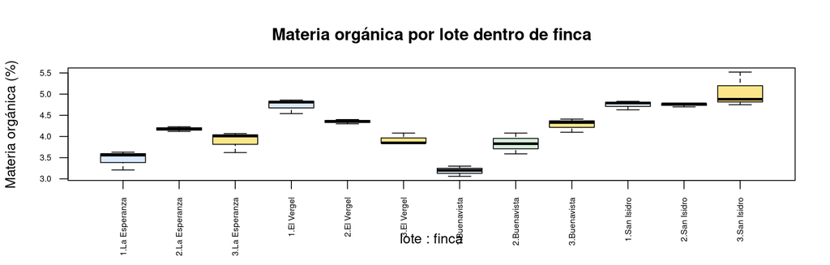

## Modelo del diseño anidado de dos etapas

Sea $i=1,\ldots,a$ el índice de finca, $j=1,\ldots,b$ el índice de lote dentro de la finca $i$, y $k=1,\ldots,n$ el índice de submuestra dentro del lote $j$ de la finca $i$.

Modelo anidado de dos etapas

$$y_{ijk} = \mu + \tau_i + \beta_{j(i)} + \varepsilon_{k(ij)}$$

- $\tau_i$: efecto de la finca $i$ ($i=1,\ldots,4$).
- $\beta_{j(i)}$: efecto del lote $j$ **anidado** en la finca $i$ ($j=1,2,3$); la notación $j(i)$ indica que el lote solo existe dentro de la finca $i$.
- $\varepsilon_{k(ij)}$: error de la submuestra $k$ dentro del lote $j$ de la finca $i$, con $\varepsilon_{k(ij)}\sim N(0,\sigma^2)$.
- En este ejemplo: finca es un factor fijo y lote es un factor aleatorio (los lotes se seleccionaron al azar dentro de cada finca).

## Descomposición de la suma de cuadrados

La variabilidad total se descompone en tres fuentes: entre fincas, entre lotes dentro de fincas, y dentro de lotes (error).

Identidad del anidado de dos etapas

$$\underbrace{\sum_{i}\sum_{j}\sum_{k}(y_{ijk}-\bar y_{...})^2}_{SC_T}
=
\underbrace{bn\sum_i (\bar y_{i..}-\bar y_{...})^2}_{SC_A}
+
\underbrace{n\sum_i\sum_j (\bar y_{ij.}-\bar y_{i..})^2}_{SC_{B(A)}}
+
\underbrace{\sum_i\sum_j\sum_k (y_{ijk}-\bar y_{ij.})^2}_{SC_E}$$

$SC_A$: variabilidad entre fincas ($a-1$ gl).

$SC_{B(A)}$: variabilidad entre lotes dentro de finca ($a(b-1)$ gl).

$SC_E$: variabilidad entre submuestras dentro de lote ($ab(n-1)$ gl).

## Tabla ANOVA del diseño anidado: estructura

| Fuente | SC | gl | CM | F |
| --- | --- | --- | --- | --- |
| Finca (A) | $SC_A$ | $a-1$ | $CM_A$ | $CM_A/CM_{B(A)}$ |
| Lote dentro de finca B(A) | $SC_{B(A)}$ | $a(b-1)$ | $CM_{B(A)}$ | $CM_{B(A)}/CM_E$ |
| Error | $SC_E$ | $ab(n-1)$ | $CM_E$ |  |
| Total | $SC_T$ | $abn-1$ |  |  |

Punto clave: el factor finca se prueba contra $CM_{B(A)}$ (no contra $CM_E$), porque el lote es la unidad experimental real para el efecto de finca.

## Resultado del ejemplo: tabla ANOVA completa

| Fuente | SC | gl | CM | F | valor-p |
| --- | --- | --- | --- | --- | --- |
| Finca | 6.780 | 3 | 2.260 | 4.81 | 0.034 |
| Lote (Finca) | 3.755 | 8 | 0.469 | 12.59 | $6.5\times10^{-7}$ |
| Error | 0.895 | 24 | 0.037 |  |  |
| Total | 11.430 | 35 |  |  |  |

$F_{Finca}=CM_A/CM_{B(A)}=2.260/0.469=4.81$ $F_{Lote(Finca)}=CM_{B(A)}/CM_E=0.469/0.037=12.59$

## Criterio de decisión y conclusión

Efecto de Finca

$$F_{calc}=4.81 > F_{0.05,3,8}=4.07$$
$$\text{valor-p}=0.034<0.05$$
Se rechaza $H_0$: hay diferencias entre fincas.

Efecto de Lote (Finca)

$$F_{calc}=12.59 > F_{0.05,8,24}=2.36$$
$$\text{valor-p}=6.5\times10^{-7}<0.05$$
Se rechaza $H_0$: hay variación entre lotes.

Conclusión: tanto la finca como el lote dentro de finca contribuyen significativamente a la variabilidad de la materia orgánica del suelo. San Isidro presenta el contenido promedio más alto (4.85%) y Buenavista el más bajo (3.77%).

## Verificación diagnóstica: residuos

Como en cualquier ANOVA, deben verificarse los supuestos de normalidad y homogeneidad de varianza sobre los residuos del modelo anidado.

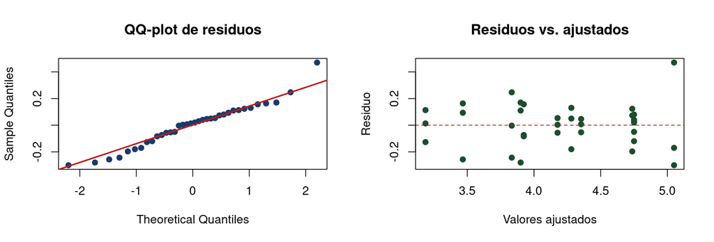

Prueba de Shapiro-Wilk sobre los residuos: $W=0.965$, valor-p $=0.310>0.05$. No hay evidencia para rechazar la normalidad; el modelo es adecuado.

## Componentes de varianza en el diseño anidado

Cuando el factor anidado (lote) es **aleatorio**, interesa estimar cuánta variabilidad total se debe a la diferencia entre lotes y cuánta al error de muestreo dentro de lote, mediante el método de momentos.

Estimadores de componentes de varianza

$$\hat\sigma^2 = CM_E \qquad\qquad \hat\sigma^2_\beta = \frac{CM_{B(A)}-CM_E}{n}$$

Con $CM_{B(A)}=0.469$, $CM_E=0.037$ y $n=3$ submuestras por lote:
$$\hat\sigma^2=0.037 \qquad\qquad \hat\sigma^2_\beta=\frac{0.469-0.037}{3}=0.144$$

La varianza entre lotes ($0.144$) es casi 4 veces mayor que la varianza dentro de lote ($0.037$): la mayor fuente de variabilidad no controlada está entre lotes, no entre submuestras.

## Interpretación práctica de los componentes de varianza

Esta descomposición tiene una implicación directa para el muestreo de suelos en fincas cafeteras.

Si $\hat\sigma^2_\beta \gg \hat\sigma^2$, conviene invertir el esfuerzo de muestreo en aumentar el **número de lotes** por finca, en lugar de aumentar el número de submuestras por lote.

Tomar 10 submuestras de un solo lote no compensa la variabilidad real entre lotes de una misma finca.

## Diseños anidados escalonados (staggered)

En el diseño anidado clásico se exige el mismo número de lotes por finca y el mismo número de submuestras por lote (diseño **balanceado**). En la práctica, el costo de muestrear submuestras adicionales en niveles inferiores de la jerarquía suele ser mucho menor que el de agregar una unidad en un nivel superior.

Un diseño anidado **escalonado** (staggered nested design) reduce deliberadamente el número de observaciones en los niveles más profundos de la jerarquía a medida que se sube de nivel, balanceando así el costo total del muestreo entre todos los niveles.

Ejemplo: en lugar de tomar 3 submuestras en cada uno de 3 lotes por finca, se podría tomar 4 submuestras en un lote, 2 en otro y 1 en el tercero, manteniendo precisión similar en la estimación de cada componente de varianza con menor costo total.

Estos diseños son útiles cuando el objetivo principal es estimar componentes de varianza (no comparar medias), y se analizan con métodos especializados de estimación de varianza por niveles.

## Errores comunes: diseño anidado

Advertencia: errores frecuentes

- Probar el efecto de finca contra $CM_E$ en lugar de $CM_{B(A)}$: produce un estadístico F inflado y conclusiones erróneas.
- Tratar lote y finca como factores cruzados (incluir una “interacción” finca $\times$ lote) cuando en realidad el lote está anidado.
- Ignorar que, si el lote es aleatorio, el denominador correcto para probar finca depende de si finca también es aleatoria o fija.
- Confundir el número de submuestras con repeticiones independientes del experimento: las submuestras solo capturan variación de muestreo dentro del lote, no entre lotes.

Generalizaciones del diseño anidado

La jerarquía de anidamiento puede extenderse a más niveles, y puede combinarse con factores cruzados.

## El diseño anidado general de m etapas

La idea del anidamiento de dos etapas se extiende naturalmente a más niveles jerárquicos. Por ejemplo, en un estudio de rendimiento de café podría existir la jerarquía: **región** $\to$ **finca** (anidada en región) $\to$ **lote** (anidado en finca) $\to$ **parcela** (anidada en lote).

Modelo anidado de m etapas

$$y_{hijk\ldots} = \mu + \alpha_h + \tau_{i(h)} + \beta_{j(hi)} + \varepsilon_{k(hij)}$$

Cada término se prueba contra el cuadrado medio del nivel **inmediatamente inferior** en la jerarquía, no contra el error de la base.

## Tabla ANOVA del diseño anidado de m etapas

| Fuente | gl | Denominador de F |
| --- | --- | --- |
| Región | $r-1$ | $CM_{Finca(Región)}$ |
| Finca (Región) | $r(f-1)$ | $CM_{Lote(Finca)}$ |
| Lote (Finca) | $rf(l-1)$ | $CM_{Parcela(Lote)}$ |
| Parcela (Lote) | $rfl(p-1)$ | $CM_{Error}$ |
| Error | por diferencia |  |

Cada nivel se prueba con el cuadrado medio del nivel inmediatamente más profundo: esta es la regla general de los “denominadores correctos” en jerarquías anidadas.

## Factores anidados y factoriales combinados

Es posible combinar un esquema factorial con un esquema anidado. Por ejemplo: dentro de cada finca cafetera se cruzan dos factores, **variedad de café** (Castillo, Caturra) y **tipo de manejo** (tradicional, tecnificado), pero ambos factores están anidados dentro de finca porque las combinaciones se distribuyen en lotes propios de cada finca.

Notación: Variedad $\times$ Manejo $(Finca)$. La interacción Variedad $\times$ Manejo es de interés directo; la finca actúa como bloque jerárquico que aporta variabilidad adicional no controlada.

Estos modelos mixtos (cruzado + anidado) son comunes en sistemas agrícolas reales, donde hay una estructura de manejo experimental dentro de unidades geográficas naturales (fincas, veredas, regiones).

Diseño de parcelas divididas (split-plot)

¿Qué hacer cuando un factor experimental es costoso o difícil de cambiar entre unidades pequeñas?

## Motivación del split-plot

En un cultivo de arroz se quiere evaluar dos **sistemas de riego** (inundación continua, goteo) y tres **variedades** (Fedearroz 60, Fedearroz 174, Oryzica). El riego requiere infraestructura fija (canales, tuberías) que solo puede instalarse en parcelas **grandes**; cambiar el sistema de riego dentro de una parcela pequeña es inviable.

Si se aleatorizara por completo (diseño factorial completamente aleatorizado), habría que construir infraestructura de riego distinta para cada combinación riego$\times$variedad: costoso e impráctico.

Solución: aplicar el riego a **parcelas grandes** (parcela principal) y, dentro de cada una, sembrar franjas de las distintas variedades (subparcela), que sí pueden asignarse al azar fácilmente.

## Estructura del diseño split-plot

Parcela principal (whole-plot)

Unidad **grande**. Recibe el factor difícil de cambiar (riego). Se aleatoriza dentro de bloques, igual que en un BCA.

Subparcela (sub-plot)

Unidad **pequeña**, dentro de la parcela principal. Recibe el factor fácil de cambiar (variedad), aleatorizado dentro de cada parcela principal.

Existen dos procesos de aleatorización independientes: uno para el factor de parcela principal entre bloques, y otro para el factor de subparcela dentro de cada parcela principal.

## Ejemplo agrícola: riego y variedad de arroz

Se establecen 3 **bloques** en un lote arrocero del Tolima. En cada bloque hay 2 parcelas principales, asignadas aleatoriamente a los sistemas de riego (Inundación, Goteo). Dentro de cada parcela principal, las 3 variedades se siembran en franjas (subparcelas) asignadas al azar.

Total de observaciones: 3 bloques $\times$ 2 riegos $\times$ 3 variedades = 18 parcelas. Variable de respuesta: rendimiento (ton/ha).

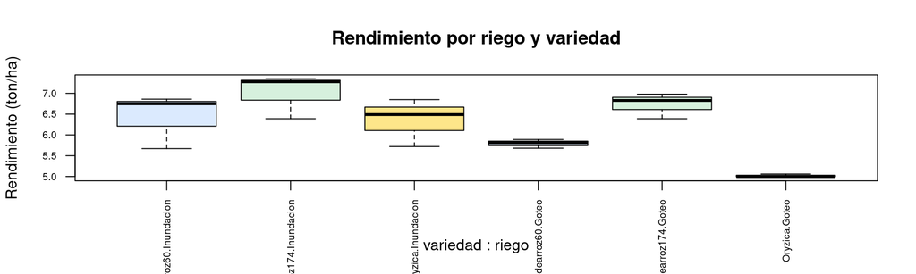

## Datos del experimento split-plot

| Bloque | Riego | Fedearroz60 | Fedearroz174 | Oryzica |
| --- | --- | --- | --- | --- |
| 1 | Inundación | 5.67 | 6.39 | 5.72 |
| 1 | Goteo | 5.81 | 6.98 | 5.00 |
| 2 | Inundación | 6.75 | 7.28 | 6.49 |
| 2 | Goteo | 5.68 | 6.39 | 4.99 |
| 3 | Inundación | 6.86 | 7.35 | 6.85 |
| 3 | Goteo | 5.89 | 6.83 | 5.06 |

Medias: Inundación = 6.60 ton/ha, Goteo = 5.85 ton/ha. Fedearroz60 = 6.11, Fedearroz174 = 6.87, Oryzica = 5.69.

## Modelo del diseño split-plot

Sea $k=1,\ldots,3$ el bloque, $i=1,2$ el sistema de riego (factor de parcela principal) y $j=1,2,3$ la variedad (factor de subparcela).

Modelo split-plot

$$y_{ijk} = \mu + \rho_k + \alpha_i + \delta_{ik} + \gamma_j + (\alpha\gamma)_{ij} + \varepsilon_{ijk}$$

- $\rho_k$: efecto del bloque. $\alpha_i$: efecto del riego (parcela principal).
- $\delta_{ik}\sim N(0,\sigma^2_\delta)$: **error de parcela principal** (whole-plot error), captura la variabilidad entre parcelas grandes dentro de un bloque.
- $\gamma_j$: efecto de variedad (subparcela). $(\alpha\gamma)_{ij}$: interacción riego$\times$variedad.
- $\varepsilon_{ijk}\sim N(0,\sigma^2)$: **error de subparcela** (sub-plot error), generalmente más pequeño que $\sigma^2_\delta$.

El modelo tiene **dos términos de error distintos**: esta es la característica que distingue al split-plot de un factorial estándar en BCA.

## Tabla ANOVA del split-plot: estructura

| Fuente | SC | gl | CM | F |
| --- | --- | --- | --- | --- |
| Bloque | $SC_{Bloque}$ | $r-1$ | $CM_{Bloque}$ | $CM_{Bloque}/CM_{Ea}$ |
| Riego (A) | $SC_A$ | $a-1$ | $CM_A$ | $CM_A/CM_{Ea}$ |
| Error(a) [whole-plot] | $SC_{Ea}$ | $(r-1)(a-1)$ | $CM_{Ea}$ |  |
| Variedad (B) | $SC_B$ | $b-1$ | $CM_B$ | $CM_B/CM_{Eb}$ |
| Riego $\times$ Variedad | $SC_{AB}$ | $(a-1)(b-1)$ | $CM_{AB}$ | $CM_{AB}/CM_{Eb}$ |
| Error(b) [sub-plot] | $SC_{Eb}$ | $a(r-1)(b-1)$ | $CM_{Eb}$ |  |

Regla del denominador correcto: los efectos de parcela principal (Bloque, Riego) se prueban contra $CM_{Ea}$; los efectos de subparcela y la interacción se prueban contra $CM_{Eb}$.

## Resultado del ejemplo: tabla ANOVA split-plot

| Fuente | SC | gl | CM | F | valor-p |
| --- | --- | --- | --- | --- | --- |
| Bloque | 0.907 | 2 | 0.453 | 0.71 | 0.584 |
| Riego | 2.516 | 1 | 2.516 | 3.96 | 0.185 |
| Error(a) | 1.272 | 2 | 0.636 |  |  |
| Variedad | 4.325 | 2 | 2.162 | 124.62 | $<0.001$ |
| Riego $\times$ Variedad | 0.877 | 2 | 0.439 | 25.28 | $<0.001$ |
| Error(b) | 0.139 | 8 | 0.017 |  |  |

$F_{Riego}=2.516/0.636=3.96$ (vs. $CM_{Ea}$) $F_{Variedad}=2.162/0.017=124.62$ (vs. $CM_{Eb}$) $F_{R\times V}=0.439/0.017=25.28$ (vs. $CM_{Eb}$)

## Criterio de decisión: efecto de riego (parcela principal)

$$F_{calc}=3.96 \quad \text{vs.} \quad F_{0.05,1,2}=18.51$$
$$\text{valor-p}=0.185>0.05$$
No se rechaza $H_0$: con solo $2$ grados de libertad para Error(a), no hay evidencia suficiente de diferencia entre sistemas de riego.

Aunque la diferencia muestral es grande (6.60 vs. 5.85 ton/ha), el error de parcela principal tiene muy pocos grados de libertad (solo 2), lo que limita drásticamente la potencia de esta prueba.

## Criterio de decisión: efecto de variedad y de interacción

**Variedad:** $F_{calc}=124.62 > F_{0.05,2,8}=4.46$, valor-p $<0.001$. Se rechaza $H_0$: las variedades difieren significativamente en rendimiento.

**Riego $\times$ Variedad:** $F_{calc}=25.28 > F_{0.05,2,8}=4.46$, valor-p $<0.001$. Se rechaza $H_0$: el efecto de la variedad depende del sistema de riego.

## Medias de las combinaciones riego x variedad

| Riego | Fedearroz60 | Fedearroz174 | Oryzica |
| --- | --- | --- | --- |
| Inundación | 6.43 | 7.01 | 6.35 |
| Goteo | 5.79 | 6.73 | 5.02 |

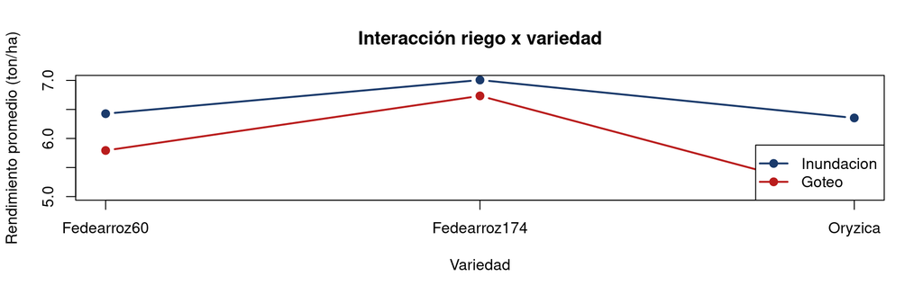

## Comparación de medias de variedad: Tukey

| Comparación | Diferencia | IC 95% | valor-p |
| --- | --- | --- | --- |
| Fedearroz174 - Fedearroz60 | 0.760 | (0.166, 1.354) | 0.014 |
| Oryzica - Fedearroz60 | -0.425 | (-1.019, 0.169) | 0.173 |
| Oryzica - Fedearroz174 | -1.185 | (-1.779, -0.591) | $<0.001$ |

Fedearroz 174 difiere significativamente de Fedearroz 60 y de Oryzica; Fedearroz 60 y Oryzica no difieren significativamente entre sí.

## Interpretación: precisión diferencial en el split-plot

Una característica fundamental del split-plot es que el factor de parcela principal se estima con **menor precisión** que el factor de subparcela.

| Fuente | CM de error | gl de error | CV (%) |
| --- | --- | --- | --- |
| Riego (whole-plot) | 0.636 | 2 | 12.82 |
| Variedad (sub-plot) | 0.017 | 8 | 2.12 |

El coeficiente de variación del whole-plot (12.82%) es seis veces mayor que el del sub-plot (2.12%): la estimación del efecto de riego es mucho menos precisa.

Implicación práctica: el factor más importante para el investigador (aquel cuyas diferencias se desean detectar con mayor precisión) debe asignarse a la **subparcela**, no a la parcela principal, siempre que el diseño lo permita.

## Errores comunes: split-plot

Advertencia: errores frecuentes

- Probar el factor de parcela principal (riego) contra $CM_{Eb}$ en lugar de $CM_{Ea}$: ignora que el riego tiene su propio error con menos grados de libertad.
- Tratar el split-plot como un factorial estándar de dos factores en BCA, lo cual ignora la estructura de dos errores y produce conclusiones incorrectas sobre el factor de parcela principal.
- Asignar al whole-plot el factor de mayor interés científico cuando podría asignarse al sub-plot, sacrificando precisión innecesariamente.
- No reportar por separado los grados de libertad de Error(a) y Error(b): son fundamentales para evaluar la potencia real de cada prueba.

Otras variaciones del split-plot

La estructura de parcelas divididas puede extenderse a más factores y a otros esquemas de asignación.

## Split-plot con más de dos factores

Es posible agregar un tercer factor dentro de la subparcela, manteniendo un solo nivel de parcela principal. Por ejemplo, además de riego (whole-plot) y variedad (sub-plot), se podría evaluar la **densidad de siembra** también a nivel de subparcela.

El modelo agrega los términos variedad $\times$ densidad y riego $\times$ variedad $\times$ densidad, todos probados contra $CM_{Eb}$, ya que ambos factores adicionales viven dentro de la subparcela.

La estructura de error sigue teniendo solo dos componentes (Error(a) y Error(b)), siempre que todos los factores adicionales se asignen y aleatoricen dentro de la subparcela.

## El diseño split-split-plot

Cuando existen **tres** niveles de dificultad para cambiar los factores, se introduce un tercer nivel de unidad experimental: la **sub-subparcela** (split-split-plot).

**Parcela principal**  
Riego (difícil de cambiar)

**Subparcela**  
Variedad (cambio intermedio)

**Sub-subparcela**  
Dosis de fertilizante (fácil de cambiar)

Este modelo tiene **tres** términos de error (whole-plot, sub-plot y sub-sub-plot), cada uno con sus propios grados de libertad; cada factor se prueba contra el error de su propio nivel jerárquico.

## El diseño en franjas divididas (strip-split-plot)

En el diseño en **franjas divididas** (strip-plot), ambos factores principales se aplican en franjas que se **cruzan** perpendicularmente dentro de cada bloque, en lugar de que uno esté anidado dentro del otro.

Ejemplo: en un lote de caña panelera, el **sistema de riego** se aplica en franjas horizontales y la **variedad** se aplica en franjas verticales que atraviesan todas las franjas de riego. Cada celda de la cuadrícula resultante es la intersección de una franja de riego y una franja de variedad.

A diferencia del split-plot clásico, aquí **ambos** factores tienen su propio error de franja (error de fila y error de columna), y la interacción se prueba con un tercer error, generalmente más preciso que los dos anteriores.

Se usa cuando ambos factores son igualmente difíciles de cambiar dentro de la unidad pequeña, pero es factible aplicarlos en franjas cruzadas (ej. limitaciones de maquinaria agrícola en ambas direcciones de siembra).

## Resumen general de la clase

Diseño

Estructura

Errores

Anidado de 2 etapas

Lote dentro de finca

1 error (submuestra)

Anidado de m etapas

Región > finca > lote > parcela

Jerarquía de denominadores

Split-plot

Riego (whole-plot) $\times$ variedad (sub-plot)

2 errores

Split-split-plot

- dosis (sub-sub-plot)

3 errores

Strip-split-plot

Franjas cruzadas de riego y variedad

3 errores (fila, columna, intersección)

La regla común a todos estos diseños: cada efecto se prueba contra el cuadrado medio del error correspondiente a su propio nivel de unidad experimental.

## Taller en Clase

## Instrucciones

Para cada ejercicio:

1. Identifique si la estructura es anidada, factorial, split-plot o una combinación.
2. Plantee el modelo estadístico y las hipótesis correspondientes.
3. Construya o complete la tabla ANOVA usando el denominador correcto para cada F.
4. Aplique el criterio de decisión con el valor crítico o el valor-p indicado.
5. Redacte una conclusión en el contexto agrícola del problema.

## Ejercicio 1

Problema

Un ganadero evalúa la producción de leche (litros/día) en 3 hatos de la Sabana de Bogotá. En cada hato se seleccionan al azar 4 vacas (anidadas en hato), y cada vaca se mide en 2 ordeños (mañana y tarde). El ANOVA arroja $SC_{Hato}=18.6$ (2 gl), $SC_{Vaca(Hato)}=42.3$ (9 gl) y $SC_E=8.1$ (12 gl).

Utilice: $F_{0.05,2,9}=4.26$ y $F_{0.05,9,12}=2.80$

## Ejercicio 2

Problema

En una finca floricultora de Cundinamarca se evalúan 2 tipos de invernadero (whole-plot, en 4 bloques) y 3 variedades de rosa (sub-plot). El software reporta: Bloque $SC=3.2$ (3 gl), Invernadero $SC=14.5$ (1 gl), Error(a) $SC=6.4$ (3 gl), Variedad $SC=22.1$ (2 gl), Invernadero$\times$Variedad $SC=5.8$ (2 gl), Error(b) $SC=4.2$ (12 gl).

Utilice: $F_{0.05,1,3}=10.13$ y $F_{0.05,2,12}=3.89$

## Ejercicio 3

Problema

Un ingenio azucarero del Valle del Cauca mide el contenido de sacarosa (%) en cañaduzales con la jerarquía: zona $\to$ finca (anidada en zona) $\to$ lote (anidado en finca). Hay 2 zonas, 3 fincas por zona y 4 lotes por finca. ¿Cuál es el denominador correcto del estadístico F para probar el efecto de zona? ¿Y para probar el efecto de finca?

Justifique su respuesta usando la jerarquía de anidamiento.

## Ejercicio 4

Problema

## Ejercicio 5

Problema

Un agrónomo del Eje Cafetero diseña un experimento split-split-plot: sistema de sombrío (whole-plot, 2 niveles), variedad de café (sub-plot, 3 niveles) y dosis de fertilizante (sub-sub-plot, 3 niveles), con 3 bloques. Dibuje (describa en palabras) la estructura de aleatorización de las tres unidades experimentales y enumere los términos de error que tendría la tabla ANOVA.

Indique contra qué error se probaría cada uno de los tres factores principales.